# R Notebook

Problem #3

Another manufacturer approaches the hospital with an improved, but more expensive, test with the following properties

p(positive result | person has disease) = 0.96 p(negative result| person does not have disease) = 0.95

1. With this test, how many times on average must the test be repeated to achieve the hospital’s requirements for patients with and without the disease?
2. Considering only the cost of the test, and assuming the hospital will screen one million patients with a background prevalence of 0.1%, at about what price point for running the test one time will the hospital save money by switching to the new test?

-(1) - For disease:

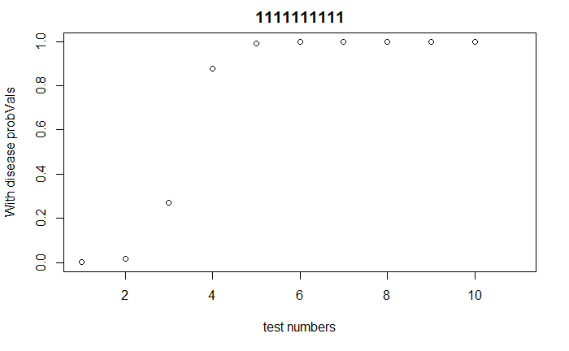

```r
# prob with disease; prob without disease
prior_tests <-  c(0.001,0.999)

# p(positive) , p(negative)
likelihooddisease <- c( 0.96, 0.04)
likelihoodNotdisease<- c(0.05,0.95)

#A function which takes in likelihood number and number of test
getDataFromLikelihood <- function( likelihood, numPoints)
{
    d <- vector(mode="integer", length=numPoints);

    # for loop the number of test
    #the 1 is for the positive result; 2 is for the negative result
    for( i in 1:numPoints )
    {
      #This is for taking with disease as number 1.
        if( runif(1) <= likelihood[1] )
        {
            d[i] <- 1; #this is for with disease
        }
        else
        {
            d[i] <- 2; # this is for without the disease
        }

    }

    return(d)
}


#get our simulated data for disease patients and number of test be done
data <- getDataFromLikelihood(likelihooddisease, 10)

#Empty vector to store the posterior probability with disease.
probVals_Disease <- vector();

#This is for the title to add with disease number 1
titleStr <- ""

#for loop for the length of the data taken for stimulation
for( i in 1:length(data))
{
  #taking posterior probability of with disease and saved in the empty vector probvals with disease
    probVals_Disease[i] <- prior_tests[1];

    #Calculating the marginal probability for a test
    denom <- prior_tests[1] * likelihooddisease[data[i]] + prior_tests[2] * likelihoodNotdisease[data[i]];

    #Calculating the posterior probability with disease and without disease
    prior_tests[1] = prior_tests[1] * likelihooddisease[data[i]] / denom;
  prior_tests[2] = prior_tests[2] * likelihoodNotdisease[data[i]] / denom;


    titleStr <- paste(titleStr,data[i],sep="")
    Sys.sleep(1);# suspend execution of R for some time interval
}
#Plotting the graph for posterior probability with disease:
plot(1:i,probVals_Disease, main = titleStr,ylim=c(0,1),xlim=c(1,length(data)+1),xlab = "test numbers", ylab= "With disease probVals")
```

```r
count = 1
for (i in probVals_Disease){
  if (i >= 0.9999){
    break
  }
  else{
    count = count + 1
    next
  }
}
print(paste("The number of test required for patients with disease:", count))
```

```
[1] "The number of test required for patients with disease: 7"
```

- For without disease:

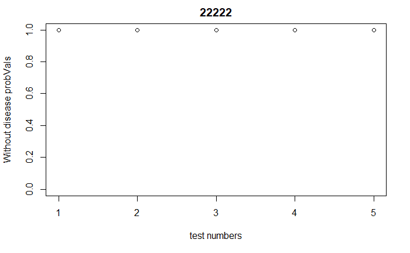

```r
# prob with disease; prob without disease
prior_tests <-  c(0.001,0.999)

# p(positive) , p(negative)
likelihooddisease <- c( 0.96, 0.04)
likelihoodNotdisease<- c(0.05,0.95)

#A function which takes in likelihood number and number of test
getDataFromLikelihood <- function( likelihood, numPoints)
{
    d <- vector(mode="integer", length=numPoints);

    # for loop the number of test
    #the 1 is for the positive result; 2 is for the negative result
    for( i in 1:numPoints )
    {
      #This is for taking with disease as number 1.
        if( runif(1) <= likelihood[1] )
        {
            d[i] <- 1; #this is for with disease
        }
        else
        {
            d[i] <- 2; # this is for without the disease
        }

    }

    return(d)
}


#get our simulated data for without disease patients and number of test be done
data <- getDataFromLikelihood(likelihoodNotdisease, 5)

#Empty vector to store the posterior probability without disease.
probVals_notDisease <- vector();

#This is for the title to add without disease number 2
titleStr <- ""

#for loop for the length of the data taken for stimulation
for( i in 1:length(data))
{
  #taking posterior probability of without disease and saved in the empty vector probvals without disease
    probVals_notDisease[i] <- prior_tests[2];

    #Calculating the marginal probability for a test
    denom <- prior_tests[1] * likelihooddisease[data[i]] + prior_tests[2] * likelihoodNotdisease[data[i]];

    #Calculating the posterior probability with disease and without disease
    prior_tests[1] = prior_tests[1] * likelihooddisease[data[i]] / denom;
  prior_tests[2] = prior_tests[2] * likelihoodNotdisease[data[i]] / denom;


    titleStr <- paste(titleStr,data[i],sep="")# this is to add the title for the graph
    Sys.sleep(1);# suspend execution of R for some time interval
}
#Plotting the graph for posterior probability without disease:
plot(1:i,probVals_notDisease, main = titleStr,ylim=c(0,1),xlim=c(1,length(data)),xlab = "test numbers", ylab= "Without disease probVals")
```

```r
count = 1
for (i in probVals_notDisease){
  if (i >= 0.9999){
    break
  }
  else{
    count = count + 1
    next
  }
}
print(paste("The number of test required for patients without disease:", count))
```

```
[1] "The number of test required for patients without disease: 2"
```

- With the disease the number of tests that must be repeated are almost 7 and without the disease it should be 2 to meet the hospital requirement.

-(2) what price point for running the test one time will the hospital save money by switching to the new test? - For running the test one time:

```r
budget <- 1000000 * 0.001 * 7 + 1000000 * 0.999 * 2
print(paste("The hospital budget required to run this test is:", budget))
```

```
[1] "The hospital budget required to run this test is: 2005000"
```